# Bowtie, Bowtie 2 and HISAT thread scaling results

All of these results are based on the output of the [`master.py`](https://github.com/BenLangmead/bowtie-scaling/blob/master/thread_scaling/scripts/master.py) and [`master_tabulate.py`](https://github.com/BenLangmead/bowtie-scaling/blob/master/thread_scaling/scripts/master_tabulate.py) scripts in the [`bowtie-scaling`](https://github.com/BenLangmead/bowtie-scaling) repo.

```r
library(dplyr)
```

```r
library(ggplot2)
```

```r
m <- read.table('showcase2016/results_showcase_2016.tsv', header=T, sep='\t')
head(m)
```

```
##     experiment                 run   tool               lock
## 1 showcase2016 bt-tbbpin-co-tktptl bowtie TBB/JHU CohortLock
## 2 showcase2016 bt-tbbpin-co-tktptl bowtie TBB/JHU CohortLock
## 3 showcase2016 bt-tbbpin-co-tktptl bowtie TBB/JHU CohortLock
## 4 showcase2016 bt-tbbpin-co-tktptl bowtie TBB/JHU CohortLock
## 5 showcase2016 bt-tbbpin-co-tktptl bowtie TBB/JHU CohortLock
## 6 showcase2016 bt-tbbpin-co-tktptl bowtie TBB/JHU CohortLock
##            version sensitivity paired threads seconds
## 1 Original parsing   sensitive     pe      90  77.062
## 2 Original parsing   sensitive     pe      75  76.609
## 3 Original parsing   sensitive     pe      60  81.127
## 4 Original parsing   sensitive     pe      15  60.334
## 5 Original parsing   sensitive     pe     105  84.476
## 6 Original parsing   sensitive     pe       1  61.712
```

## Bowtie

Configurations tested. TODO: de-uglify this table.

```
bt-cleanparse-tt                bowtie  scaling             WITH_THREAD_PROFILING=1 EXTRA_FLAGS="-DUSE_FINE_TIMER"  -I 250 -X 800
bt-cleanparse-tbbpin-spin         bowtie    scaling             WITH_THREAD_PROFILING=1 EXTRA_FLAGS="-DUSE_FINE_TIMER" WITH_TBB=1 WITH_AFFINITY=1   -I 250 -X 800
bt-cleanparse-tbbpin-heavy      bowtie  scaling             WITH_THREAD_PROFILING=1 EXTRA_FLAGS="-DUSE_FINE_TIMER" WITH_TBB=1 WITH_AFFINITY=1 NO_SPINLOCK=1 -I 250 -X 800
bt-cleanparse-tbbpin-q          bowtie  scaling             WITH_THREAD_PROFILING=1 EXTRA_FLAGS="-DUSE_FINE_TIMER" WITH_TBB=1 WITH_AFFINITY=1 NO_SPINLOCK=1 WITH_QUEUELOCK=1    -I 250 -X 800
#bt-cleanparse-tbbpin-co-q      bowtie  scaling             WITH_THREAD_PROFILING=1 EXTRA_FLAGS="-DUSE_FINE_TIMER" WITH_TBB=1 WITH_AFFINITY=1 WITH_QUEUELOCK=1 WITH_COHORTLOCK=1    -I 250 -X 800
bt-cleanparse-tbbpin-co-tktptl  bowtie  scaling             WITH_THREAD_PROFILING=1 EXTRA_FLAGS="-DUSE_FINE_TIMER" WITH_TBB=1 WITH_AFFINITY=1 WITH_COHORTLOCK=1 -I 250 -X 800
bt-tt                             bowtie    scaling-old-parsing WITH_THREAD_PROFILING=1 EXTRA_FLAGS="-DUSE_FINE_TIMER"  -I 250 -X 800
bt-no-io                          bowtie    no-io                 WITH_THREAD_PROFILING=1 EXTRA_FLAGS="-DUSE_FINE_TIMER" WITH_TBB=1 WITH_AFFINITY=1 -I 250 -X 800
bt-tbbpin-spin                  bowtie  scaling-old-parsing WITH_THREAD_PROFILING=1 EXTRA_FLAGS="-DUSE_FINE_TIMER" WITH_TBB=1 WITH_AFFINITY=1   -I 250 -X 800
bt-tbbpin-heavy                 bowtie  scaling-old-parsing WITH_THREAD_PROFILING=1 EXTRA_FLAGS="-DUSE_FINE_TIMER" WITH_TBB=1 WITH_AFFINITY=1 NO_SPINLOCK=1 -I 250 -X 800
bt-tbbpin-q                     bowtie  scaling-old-parsing WITH_THREAD_PROFILING=1 EXTRA_FLAGS="-DUSE_FINE_TIMER" WITH_TBB=1 WITH_AFFINITY=1 NO_SPINLOCK=1 WITH_QUEUELOCK=1    -I 250 -X 800
#bt-tbbpin-co-q                 bowtie  scaling-old-parsing WITH_THREAD_PROFILING=1 EXTRA_FLAGS="-DUSE_FINE_TIMER" WITH_TBB=1 WITH_AFFINITY=1 WITH_QUEUELOCK=1 WITH_COHORTLOCK=1    -I 250 -X 800
bt-tbbpin-co-tktptl             bowtie  scaling-old-parsing WITH_THREAD_PROFILING=1 EXTRA_FLAGS="-DUSE_FINE_TIMER" WITH_TBB=1 WITH_AFFINITY=1 WITH_COHORTLOCK=1 -I 250 -X 800
```

### Bowtie unpaired

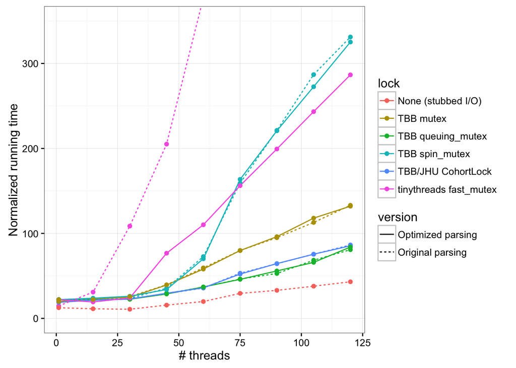

```r
mtmp <- m %>% filter(tool == 'bowtie' & paired == 'unp')
ggplot(mtmp, aes(x=threads, y=seconds, color=lock, linetype=version)) +
  geom_line() + geom_point() + theme_bw() +
  labs(y="Normalized running time", x="# threads") +
  coord_cartesian(ylim=c(0, 350))
```

A few remarkable things: * Tinythreads with original parsing is terrible * Looking at the 1-thread result (extreme left), there’s a big difference between `bt-no-io` and everyone else. Why would there be a difference *for a single thread*? Examining in gdb, I noticed when the `tbb:task_group` is created, this creates *several* threads – i.e. several messages like `New Thread 0x7fff69755700 (LWP 3164)` – even with `-p 1`. Why several? Tinythreads only creates one with `-p 1`. * Apart from tinythreads, improved parsing has very little effect. When I use gdb to investigate where time is being spent for, e.g., `bt-cleanparse-tbbpin-q` 120-threads, it’s clearly the case that most threads are waiting for the input lock. So the big differences between the lock types suggests performance is dominated by lock overhead, not by the critical section per se.

### Bowtie paired-end

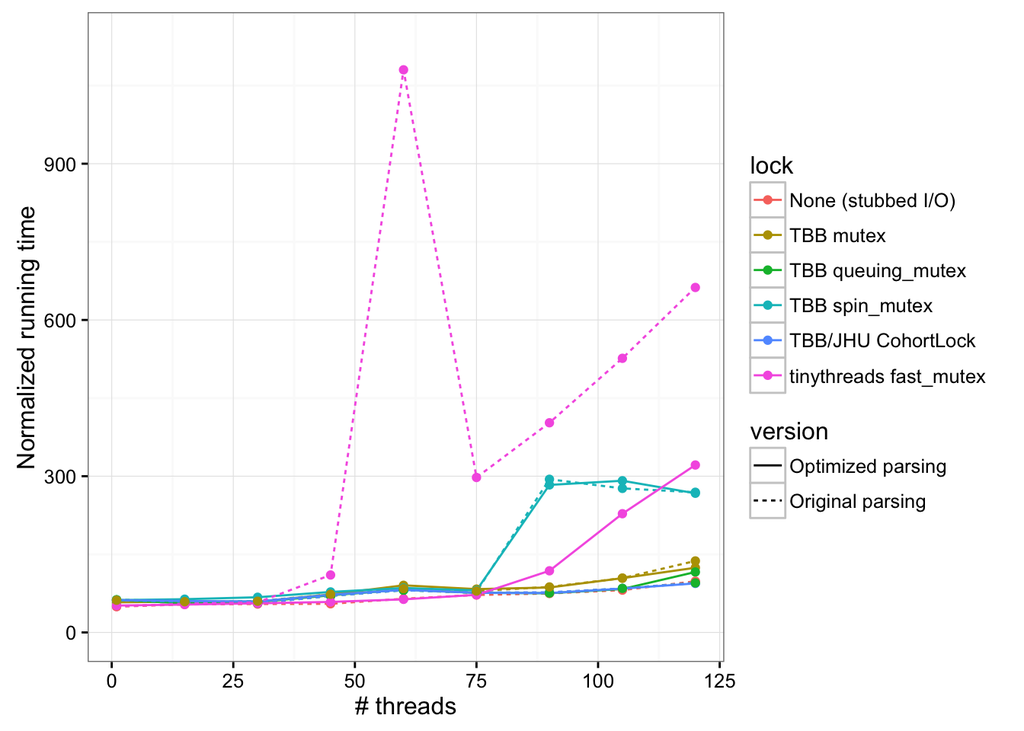

```r
mtmp <- m %>% filter(tool == 'bowtie' & paired == 'pe')
ggplot(mtmp, aes(x=threads, y=seconds, color=lock, linetype=version)) +
  geom_line() + geom_point() + theme_bw() +
  labs(y="Normalized running time", x="# threads") +
  coord_cartesian(ylim=c(0, max(mtmp$seconds)*1.05))
```

- Something fishy happened for 60-thread tinythreads original parsing – super high
- Like with Bowtie unpaired results, not much evidence that cleaner parsing is making a difference. Suggests that performance differences (biggest difference is spin vs everyone else) are due to lock overhead.

## HISAT

Configurations tested:

```
hisat-tt                  hisat master          WITH_THREAD_PROFILING=1 EXTRA_FLAGS="-DUSE_FINE_TIMER"
hisat-tbbpin-q            hisat haswell         WITH_THREAD_PROFILING=1 EXTRA_FLAGS="-DUSE_FINE_TIMER" WITH_TBB=1 WITH_AFFINITY=1 NO_SPINLOCK=1 WITH_QUEUELOCK=1
hisat-cleanparse-tbbpin-q   hisat   cleaner_parsing WITH_THREAD_PROFILING=1 EXTRA_FLAGS="-DUSE_FINE_TIMER" WITH_TBB=1 WITH_AFFINITY=1 NO_SPINLOCK=1 WITH_QUEUELOCK=1
```

### HISAT unpaired

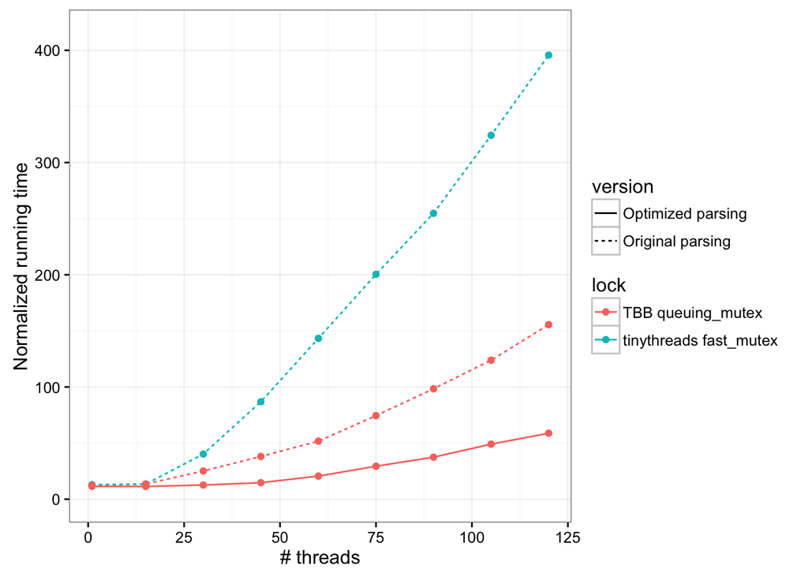

```r
mtmp <- m %>% filter(tool == 'hisat' & paired == 'unp')
ggplot(mtmp, aes(x=threads, y=seconds, color=lock, linetype=version)) +
  geom_line() + geom_point() + theme_bw() +
  labs(y="Normalized running time", x="# threads") +
  coord_cartesian(ylim=c(0, max(mtmp$seconds)*1.05))
```

- Both lock type and optimized parsing help very appreciably
- Haven’t implemented no-io yet, so can’t compare to “ideal”

### HISAT paired-end

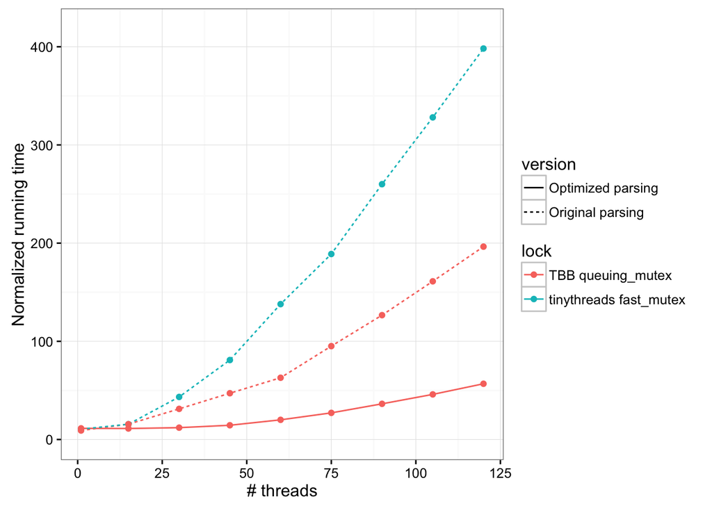

```r
mtmp <- m %>% filter(tool == 'hisat' & paired == 'pe')
ggplot(mtmp, aes(x=threads, y=seconds, color=lock, linetype=version)) +
  geom_line() + geom_point() + theme_bw() +
  labs(y="Normalized running time", x="# threads") +
  coord_cartesian(ylim=c(0, max(mtmp$seconds)*1.05))
```

(same observations as for unpaired)

## Bowtie 2

Configurations tested:

```
bt2-master  bowtie2 master  WITH_THREAD_PROFILING=1 EXTRA_FLAGS="-DUSE_FINE_TIMER"  -I 250 -X 800
bt2-tbbpin-spin bowtie2 master  WITH_THREAD_PROFILING=1 EXTRA_FLAGS="-DUSE_FINE_TIMER" WITH_TBB=1 WITH_AFFINITY=1   -I 250 -X 800
bt2-tbbpin-heavy    bowtie2 master  WITH_THREAD_PROFILING=1 EXTRA_FLAGS="-DUSE_FINE_TIMER" WITH_TBB=1 WITH_AFFINITY=1 NO_SPINLOCK=1 -I 250 -X 800
bt2-noio    bowtie2 no-io   WITH_THREAD_PROFILING=1 EXTRA_FLAGS="-DUSE_FINE_TIMER" WITH_TBB=1 WITH_AFFINITY=1   -I 250 -X 800
bt2-tbbpin-q    bowtie2 cohort_locking_ptl_tkt  WITH_THREAD_PROFILING=1 EXTRA_FLAGS="-DUSE_FINE_TIMER" WITH_TBB=1 WITH_AFFINITY=1 NO_SPINLOCK=1 WITH_QUEUELOCK=1    -I 250 -X 800
#bt2-tbbpin-co-q    bowtie2 cohort_locking_ptl_tkt  WITH_THREAD_PROFILING=1 EXTRA_FLAGS="-DUSE_FINE_TIMER" WITH_TBB=1 WITH_AFFINITY=1 WITH_QUEUELOCK=1 WITH_COHORTLOCK=1    -I 250 -X 800
bt2-tbbpin-co-tktptl    bowtie2 cohort_locking_ptl_tkt  WITH_THREAD_PROFILING=1 EXTRA_FLAGS="-DUSE_FINE_TIMER" WITH_TBB=1 WITH_AFFINITY=1 WITH_COHORTLOCK=1 -I 250 -X 800
bt2-cleanparse-tbbpin-spin  bowtie2 cleaner_parsing WITH_THREAD_PROFILING=1 EXTRA_FLAGS="-DUSE_FINE_TIMER" WITH_TBB=1 WITH_AFFINITY=1   -I 250 -X 800
bt2-cleanparse-tbbpin-heavy bowtie2 cleaner_parsing WITH_THREAD_PROFILING=1 EXTRA_FLAGS="-DUSE_FINE_TIMER" WITH_TBB=1 WITH_AFFINITY=1 NO_SPINLOCK=1 -I 250 -X 800
bt2-cleanparse-tbbpin-q bowtie2 cleaner_parsing WITH_THREAD_PROFILING=1 EXTRA_FLAGS="-DUSE_FINE_TIMER" WITH_TBB=1 WITH_AFFINITY=1 NO_SPINLOCK=1 WITH_QUEUELOCK=1    -I 250 -X 800
#bt2-cleanparse-tbbpin-co-q bowtie2 cleaner_parsing WITH_THREAD_PROFILING=1 EXTRA_FLAGS="-DUSE_FINE_TIMER" WITH_TBB=1 WITH_AFFINITY=1 WITH_QUEUELOCK=1 WITH_COHORTLOCK=1    -I 250 -X 800
bt2-cleanparse-tbbpin-co-tktptl bowtie2 cleaner_parsing WITH_THREAD_PROFILING=1 EXTRA_FLAGS="-DUSE_FINE_TIMER" WITH_TBB=1 WITH_AFFINITY=1 WITH_COHORTLOCK=1 -I 250 -X 800
```

### Bowtie 2 unpaired

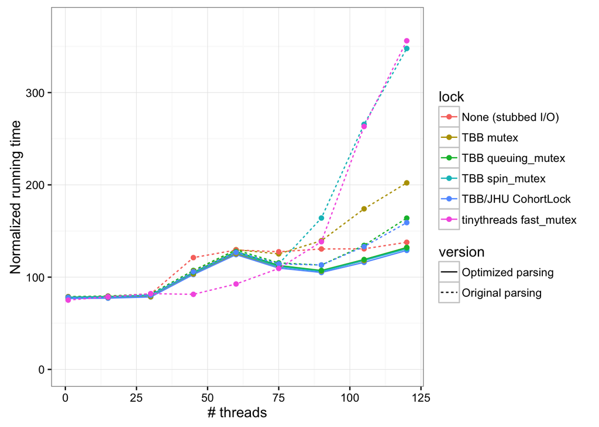

```r
mtmp <- m %>% filter(tool == 'bowtie2' & paired == 'unp')
ggplot(mtmp, aes(x=threads, y=seconds, color=lock, linetype=version)) +
  geom_line() + geom_point() + theme_bw() +
  labs(y="Normalized running time", x="# threads") +
  coord_cartesian(ylim=c(0, max(mtmp$seconds)*1.05))
```

- Optimized parsing has a huge positive benefit.
- Whether or not we use optimized parsing matters a lot. If we use optimized parsing, the different lock types don’t matter any more.
- Optimized parsing is *better* than no-io for many thread counts. This is hard to explain, and is possibly indicative of a problem with no-io mode. I forget now whether I had made the order randomization change before or after this experiment. Either way, worth running the experiment again with current HEAD of bowtie2 no-io branch.

### Bowtie 2 paired-end

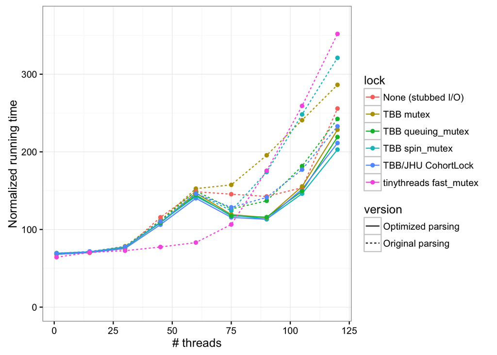

```r
mtmp <- m %>% filter(tool == 'bowtie2' & paired == 'pe')
ggplot(mtmp, aes(x=threads, y=seconds, color=lock, linetype=version)) +
  geom_line() + geom_point() + theme_bw() +
  labs(y="Normalized running time", x="# threads") +
  coord_cartesian(ylim=c(0, max(mtmp$seconds)*1.05))
```

- Very similar to Bowtie 2 unpaired but with less of a pronounced difference between optimized and original parsing

All results here are from `--sensitive` mode. I’ve noticed appreciably different results in `--very-fast` mode. I didn’t run that mode for the showcase.

## Discussion

We have an idea we haven’t tried yet for alleviating lock overhead. We can make our `readLight`/`readPairLight` functions read multiple records at a time. Within a thread, every (say) 10 calls to `readLight`/`readPairLight` actually causes synchronization & parsing to happen. For the rest, we simply change a `ReadBuf*` to point to the next already-lightly-parsed read. `finalize` remains the same.